# StatisticalInference_CourseProj

Herpich

Monday, November 17, 2014

The first part of the course project examines an exponential distribution, whose pdf takes the form f(x;lambda) = lambda * e ^ (-lambda * x) for x >= 0. In this assignment, I assume lambda = 0.2. I know that for an exponential distribution, the mean and standard deviation both equal 1/lambda, or in this case 5.

I first start with plotting the probability density function and cumulative distribution function for the exponential distribution with lambda 0.2. I know that the mean will be 5 and the median will be ln2/0.2 = 3.465, so Fx should show 50% at x = 3.465.

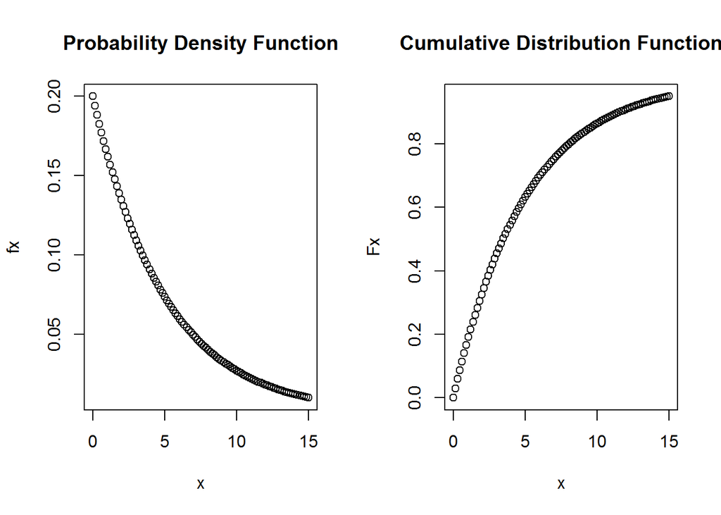

```r
x <- seq(0,15,length=100)
fx <- dexp(x, 0.2)
Fx <- pexp(x, 0.2)
par(mfrow=c(1,2))
plot(x,fx,main="Probability Density Function")
plot(x,Fx,main="Cumulative Distribution Function")
```

I then generate 40 random exponentials with lambda 0.2 and plot a histogram. I would expect this histogram to have the general shape of fx plotted above. Given the Central Limit Theorem, I know that for large enough n, a plot of the distribution of the average of 40 random exponentials with lambda 0.2 will be approximately normally distributed. For purposes of this exercise, I have run 1,000 instances. The two plots are shown below.

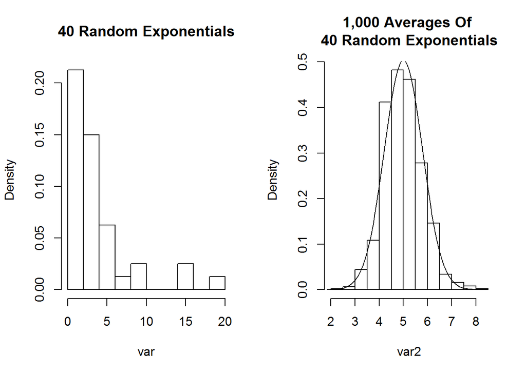

```r
var <- NULL
for (i in 1:40) var <- c(var, rexp(1,0.2))
var2 <- NULL
for (i in 1:1000) var2 <- c(var2,mean(rexp(40,0.2)))
par(mfrow=c(1,2))
normx <- seq(-4,4,length=100)*0.79 + 5
normhx <- dnorm(normx,5,0.79)
hist(var, freq=F, main="40 Random Exponentials")
hist(var2, freq=F, main = "1,000 Averages Of \n40 Random Exponentials")
lines(normx,normhx)
```

The behavior of the second plot is exactly as one would expect: the sample mean is centered at 5, the sample variance is (5)^2/40 = 0.625, and the sample error is 5/sqrt(40) = 0.79. This is demonstrated by overlaying a normal distribution with mean 5 and standard deviation 0.79 over the histogram and by calculating the values as shown below.

```r
##Sample mean (expected 5):
mean(var2)
```

```
## [1] 4.992826
```

```r
##Sample variance (expected 0.625):
var(var2)
```

```
## [1] 0.6222967
```

```r
##Standard error (expected 0.79):
sd(var2)
```

```
## [1] 0.7888578
```